# Homework 12

### Comparing Differential Expression

In order to compare differential expression I was forced to use counts from tophat2 and kallisto and input the raw counts into DESeq2. Kallisto outputs a column per sample called, estimated_counts, so I used those as counts for kallisto while for tophat I used a combination of bedtools intersect and groupby looking over exonic intervals to calculate how many reads overlapped each transcript.

The following script takes care of that.

```r
# load libraries
require(dplyr, quietly=TRUE)
require(readr, quietly=TRUE)
require(DESeq2, quietly=TRUE)

# information to load the files and create DESeq2 data structure
sample_list <- c("LT", "SC")
colData <- data.frame(condition = c("LT", "SC"), type = c("paired-end", "paired-end"))

# KALLISTO ====================================================================

# import files
for(i in 1:length(sample_list)){
  tmp <- read_tsv(file = paste0("../projects/plasmo/", sample_list[i], "_kallisto/grouped_abundances.tsv"))
  assign(sample_list[i], tmp)
}

# manipulate data for DESeq2 to read
counts <- inner_join(LT, SC, by = "target_id")[,c(1,4,8)]
rownames(counts) <- counts$target_id
counts$target_id <- NULL
colnames(counts) <- c("LT", "SC")
counts$LT <- as.integer(counts$LT)
counts$SC <- as.integer(counts$SC)

# calculate differential expression and save result
dds <- DESeqDataSetFromMatrix(countData = counts, colData = colData, design = ~ condition)
dds <- DESeq(dds)
res_kallisto <- results(dds)

# TOPHAT2 =====================================================================

# import files
for(i in 1:length(sample_list)){
  tmp <- read_tsv(file = paste0("../projects/plasmo/", sample_list[i], "_tophat/counts.tsv"))
  assign(sample_list[i], tmp)
}

# manipulate data for DESeq2 to read
colnames(LT) <- c("target_id", "LT")
colnames(SC) <- c("target_id", "SC")
counts <- inner_join(LT, SC, by = "target_id")
rownames(counts) <- counts$target_id
counts$target_id <- NULL

# calculate differential expression and save result
dds <- DESeqDataSetFromMatrix(countData = counts, colData = colData, design = ~ condition)
dds <- DESeq(dds)
res_tophat <- results(dds)
```

To start let’s look at summaries of both.

```r
summary(res_tophat)
```

```
##
## out of 406 with nonzero total read count
## adjusted p-value < 0.1
## LFC > 0 (up)     : 2, 0.49%
## LFC < 0 (down)   : 3, 0.74%
## outliers [1]     : 0, 0%
## low counts [2]   : 21, 5.2%
## (mean count < 38.6)
## [1] see 'cooksCutoff' argument of ?results
## [2] see 'independentFiltering' argument of ?results
```

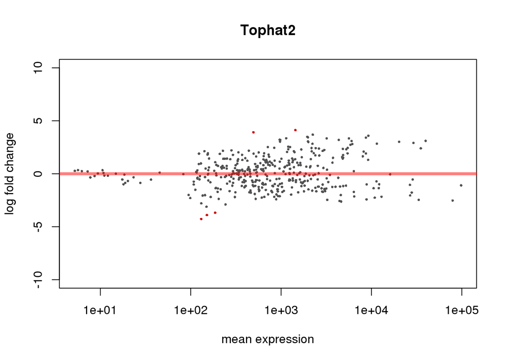

```r
plotMA(res_tophat, main="Tophat2", ylim=c(-10,10))
```

```r
summary(res_kallisto)
```

```
##
## out of 403 with nonzero total read count
## adjusted p-value < 0.1
## LFC > 0 (up)     : 14, 3.5%
## LFC < 0 (down)   : 0, 0%
## outliers [1]     : 0, 0%
## low counts [2]   : 322, 80%
## (mean count < 770)
## [1] see 'cooksCutoff' argument of ?results
## [2] see 'independentFiltering' argument of ?results
```

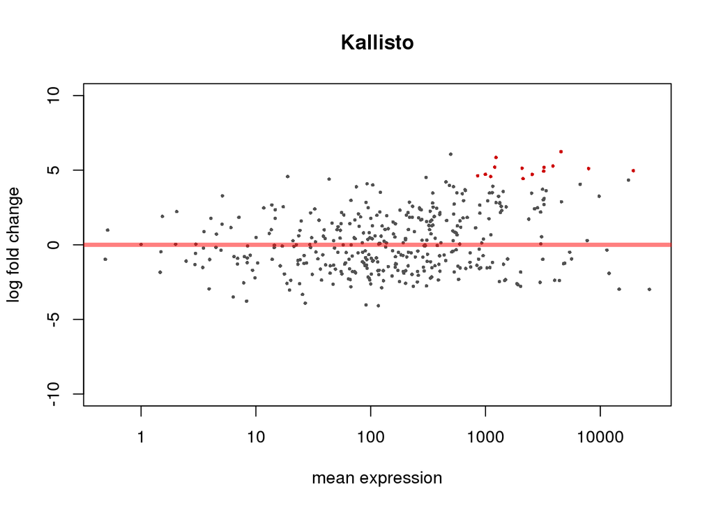

```r
plotMA(res_kallisto, main="Kallisto", ylim=c(-10,10))
```

So that’s all nice and good. We can see that the majority of trancripts are not being reported as differentially expressed and that there are more for kallisto than for tophat. But what do the distribution of p-values look like?

```r
tophat_df <- data.frame(gene_id = rownames(res_tophat), val = res_tophat[,2])
kallisto_df <- data.frame(gene_id = rownames(res_kallisto), val = res_kallisto[,2])

df <- inner_join(tophat_df, kallisto_df, by = "gene_id")
```

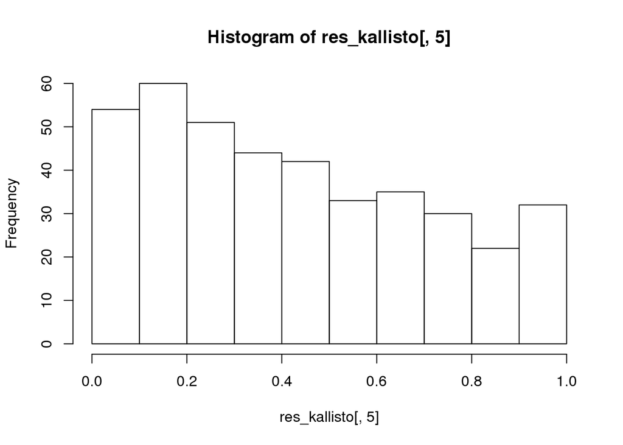

```r
colnames(df) <- c("gene_id", "tophat", "kallisto")

hist(res_kallisto[,5])
```

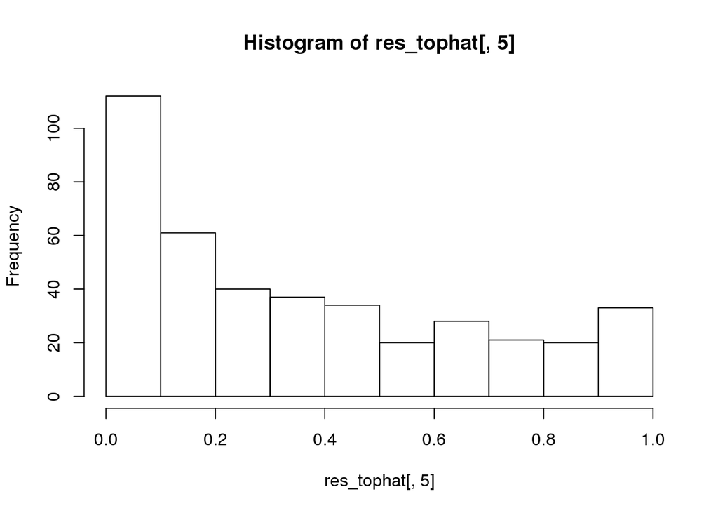

```r
hist(res_tophat[,5])
```

So from the looks of this it seems like the kallisto method is more conservative for some reason. What if we look at the log2 fold change values per transcript. Are they extremely different from one another or do they mostly follow a nice correlated relationship?

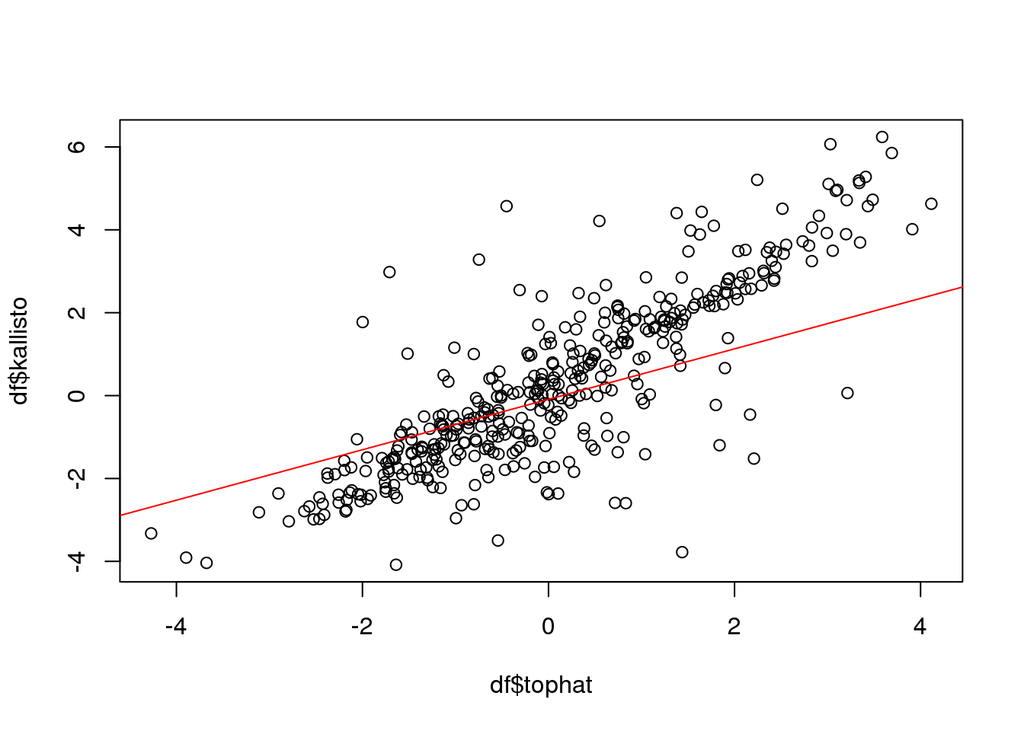

```r
fit <- lm(df$tophat ~ df$kallisto)
plot(df$tophat, df$kallisto)
abline(fit, col="red")
```

```r
cor(df$tophat, df$kallisto, use="complete")
```

```
## [1] 0.8370602
```

It looks like the two methods are mostly in agreement!

### Other Noticeable Differences

#### BAM files differences

Kallisto output what it called psuedo SAM files. However, unlike the tophat2 accepted_hits.bam files these files were much larger and this was because by default kallisto outputs every read while the accepted_hits.bam files contain only mapped reads that pass tophat2’s default filters.

## Conclusions

Based on an initial look at the summaries it seems like the approach I took calculated a small number of differential transcripts for both count inputs. The data we’re looking at here is actually a time course between two different stages of the parasite’s life cycle so there should be some down-regulated and some upregulated transcripts.

Based on the statistical model, I assume the this was NOT the correct way to call differential transcripts for a time course or else you’d see far more significant transcripts than it shows above.